# P12 - Informe de Control y Análisis

Estabilidad del modelo predictivo frente al Undersampling

Victor Malsam - David Torres

12/09/2026

# Para qué sirve este documento

Este es **nuestro informe interno de control y comprensión del P12**. No es la presentación de YouTube ni pretende volver a ejecutar el experimento.

El trabajo pesado sigue ocurriendo donde corresponde:

```
Jupyter + LightGBM + Grid Search + Kaggle
                  |
                  v
            scripts Python
                  |
                  v
             90_RESULTADOS
                  |
                  v
      ESTE INFORME R MARKDOWN
                  |
                  v
        tablas + gráficos + control
```

La idea es simple: **cada vez que aparezcan nuevos resultados consolidados en `90_RESULTADOS`, hacemos Knit nuevamente y el informe se actualiza solo**.

El documento no vuelve a calcular el score de Kaggle ni modifica notebooks, modelos, parámetros o submissions.

# 1 Pregunta del experimento

El Problema #12 estudia:

> **¿Hasta cuánto podemos reducir los registros utilizados mediante undersampling sin deteriorar de manera relevante el comportamiento predictivo y económico del modelo?**

Los cinco escenarios son:

| Código | Escenario | Interpretación |
| --- | --- | --- |
| B100 | 100% | Baseline |
| U040 | 40% | Conserva aproximadamente 40% de CONTINUA |
| U010 | 10% | Conserva aproximadamente 10% de CONTINUA |
| U005 | 5% | Conserva aproximadamente 5% de CONTINUA |
| U001 | 1% | Conserva aproximadamente 1% de CONTINUA |

**BAJA+1 y BAJA+2 se conservan completas.** El porcentaje de undersampling se aplica sobre la clase CONTINUA; por eso el porcentaje real total conservado queda algo por encima del porcentaje nominal.

Las distintas semillas son **réplicas del mismo experimento**. Victor y David no representan experimentos distintos: las semillas de ambos **ya están integradas en un único análisis SEM1..SEM12**.

# 2 De dónde sale realmente cada dato

Esta sección es importante porque queremos poder volver dentro de varios días y saber **qué produjo cada número y qué archivo lo contiene**.

La idea central es:

> **El notebook `.ipynb` NO genera directamente la tabla maestra ni los gráficos globales.**

El notebook ejecuta el experimento de una combinación:

```
SEMILLA + ESCENARIO
```

y deja dos fuentes fundamentales:

```
1. PARAM.yml
2. archivos de submission para Kaggle
```

Después, los scripts Python consultan Kaggle, consolidan los resultados y construyen los CSV de `90_RESULTADOS`.

Finalmente, este R Markdown toma esos CSV ya consolidados y genera nuestro informe global en `91_ANALISIS/00_GLOBAL`.

El recorrido completo es:

```
NOTEBOOK .ipynb
      |
      |-- PARAM.yml
      |
      |-- kaggle/KAP12_..._800.csv
      |-- kaggle/KAP12_..._850.csv
      |-- ...
      |-- kaggle/KAP12_..._1300.csv
      |
      v
KAGGLE calcula Public Score
      |
      v
SCRIPTS PYTHON p12_01 ... p12_04
      |
      v
90_RESULTADOS/
      |
      v
P12_informe_control.Rmd
      |
      v
91_ANALISIS/00_GLOBAL/
```

## 2.1 Qué parte del notebook define el escenario y la semilla

En la celda de configuración del notebook se define la réplica que estamos ejecutando.

Ejemplo:

```r
P12_SEMILLA <- 198427

P12_ESCENARIO <- "BASELINE_100"
P12_TRAINING_PCT <- 1.00
P12_CODIGO_ESCENARIO <- "B100"

PARAM$semilla_primigenia <- P12_SEMILLA
PARAM$experimento <- paste0(
  "P12_",
  P12_CODIGO_ESCENARIO,
  "_S",
  P12_SEMILLA
)
```

Para el P12, lo que cambia entre escenarios es principalmente:

```
P12_TRAINING_PCT
```

con los valores:

```
1.00
0.40
0.10
0.05
0.01
```

La semilla cambia entre réplicas.

## 2.2 Qué parte del notebook aplica el undersampling

En la sección **Training Strategy** el notebook lleva el porcentaje del escenario a:

```r
PARAM$trainingstrategy$training_pct <- P12_TRAINING_PCT
```

Luego se construye `fold_train`.

El bloque fundamental es:

```r
set.seed(
  PARAM$semilla_primigenia,
  kind = "L'Ecuyer-CMRG"
)

dataset[, azar := runif(nrow(dataset))]

dataset[
  ,
  fold_train :=
    foto_mes %in% PARAM$trainingstrategy$training &
    (
      clase_ternaria %in% c("BAJA+1", "BAJA+2") |
      azar < PARAM$trainingstrategy$training_pct
    )
]
```

Este es el punto concreto donde se produce el undersampling.

Interpretación:

```
BAJA+1 y BAJA+2  -> se conservan
CONTINUA         -> queda según training_pct
```

Por eso un escenario `10%` significa aproximadamente **10% de CONTINUA**, no 10% de todo el dataset.

## 2.3 Qué parte del notebook cuenta los registros antes y después

Inmediatamente después de crear `fold_train`, nuestras versiones finales del notebook guardan el efecto real del undersampling dentro de:

```r
PARAM$p12$registros
```

El bloque contiene, entre otros:

```r
PARAM$p12$registros$training_antes <- dataset[
  foto_mes %in% PARAM$trainingstrategy$training,
  .N
]

PARAM$p12$registros$training_despues <- dataset[
  fold_train == TRUE,
  .N
]

PARAM$p12$registros$porcentaje_real_conservado <- round(
  100 *
  PARAM$p12$registros$training_despues /
  PARAM$p12$registros$training_antes,
  4
)
```

También quedan registrados:

```
positivos_antes
positivos_despues
negativos_antes
negativos_despues
```

Estos datos después llegan al `PARAM.yml`.

## 2.4 Qué parte del notebook calcula AUC y busca los hiperparámetros

El notebook define primero los parámetros fijos de LightGBM.

Entre ellos:

```r
max_bin = 31
learning_rate = 0.03
feature_fraction = 0.5
num_iterations = 2048
early_stopping_rounds = 200
```

Luego la función:

```r
Estimar_AUC_lightgbm <- function(x)
```

entrena cada combinación del Grid Search y recupera:

```r
AUC <- modelo_train$record_evals$valid$auc$eval[
  [modelo_train$best_iter]
]

niter <- modelo_train$best_iter
```

Es decir:

```
AUC    -> métrica de validación del modelo
niter  -> mejor iteración de boosting
```

Después el notebook evalúa las combinaciones del Grid y guarda:

```r
tb_nueva[, c("AUC", "num_iterations") :=
  Estimar_AUC_lightgbm(.SD),
  by = 1:nrow(tb_nueva)
]
```

La tabla del Grid también se escribe en:

```
tb_grid_search_01.txt
```

Finalmente se ordena por AUC y se conserva el ganador:

```r
setorder(tb_nueva, -AUC)

PARAM$out$lgbm$AUC <- tb_nueva[1, AUC]

PARAM$out$lgbm$mejores_hiperparametros <-
  as.list(tb_nueva[1])
```

De ahí salen:

```
AUC
num_leaves
min_data_in_leaf
num_iterations / niter
```

que más tarde recupera el script `p12_04_integrar_resultados.py`.

## 2.5 Qué parte del notebook genera los 11 cortes para Kaggle

En la sección:

```
Kaggle Competition Submit
```

el notebook define:

```r
PARAM$kaggle$cortes <- seq(
  800,
  1300,
  by = 50
)
```

Por lo tanto se prueban:

```
800
850
900
950
1000
1050
1100
1150
1200
1250
1300
```

Para cada corte se crea un archivo:

```r
archivo_kaggle <- paste0(
  "./kaggle/KA",
  PARAM$experimento,
  "_",
  envios,
  ".csv"
)
```

y luego se ejecuta:

```r
kaggle competitions submit
```

Por ejemplo:

```
KAP12_B100_S198427_800.csv
KAP12_B100_S198427_850.csv
...
KAP12_B100_S198427_1300.csv
```

**Importante:** el notebook genera y envía esos archivos, pero la **ganancia / Public Score no la calcula el notebook**.

La ganancia la calcula Kaggle después de recibir cada submission.

## 2.6 Qué parte del notebook guarda `PARAM.yml`

Al final de cada corrida se calcula el tiempo:

```r
P12_FIN <- Sys.time()

PARAM$ejecucion$duracion_segundos <- as.numeric(
  difftime(
    P12_FIN,
    P12_INICIO,
    units = "secs"
  )
)

PARAM$ejecucion$duracion_minutos <- round(
  PARAM$ejecucion$duracion_segundos / 60,
  2
)
```

y finalmente:

```r
write_yaml(
  PARAM,
  file = "PARAM.yml"
)
```

Por lo tanto `PARAM.yml` es la fuente local donde quedan guardados:

```
escenario
semilla
training_pct
AUC
hiperparámetros ganadores
niter
registros antes/después
porcentaje real conservado
tiempo de ejecución
```

## 2.7 Qué hace cada script Python

Una vez terminados los cinco escenarios de una semilla, usamos:

```
p12_00_PROCESAR_SEMILLA_COMPLETA.py
```

Ese script es solamente un **orquestador**. No entrena modelos y no modifica Kaggle.

Ejecuta en orden:

```
p12_01_descargar_submissions.py
        |
        v
p12_02_consolidar_kaggle.py
        |
        v
p12_03_analizar_cortes.py
        |
        v
p12_04_integrar_resultados.py
```

### 2.7.1 Paso 1 - `p12_01_descargar_submissions.py`

Consulta Kaggle en modo lectura:

```
kaggle competitions submissions
```

y descarga los resultados que Kaggle ya calculó.

Genera:

```
90_RESULTADOS/
    kaggle_submissions_completo.csv

90_RESULTADOS/SEMx_SEED/
    kaggle_SEMx_SEED_RAW.csv
```

El `RAW` contiene las submissions encontradas para esa semilla, incluyendo el `publicScore`.

### 2.7.2 Paso 2 - `p12_02_consolidar_kaggle.py`

Toma el `RAW`.

Si un mismo archivo fue enviado más de una vez, conserva la submission **más reciente**.

Después exige:

```
5 escenarios × 11 cortes = 55 submissions
```

Si están las 55, genera:

```
kaggle_SEMx_SEED_FINAL.csv
```

Si falta alguna, no genera el FINAL y detiene el procesamiento.

### 2.7.3 Paso 3 - `p12_03_analizar_cortes.py`

Toma:

```
kaggle_SEMx_SEED_FINAL.csv
```

y trabaja con:

```
fileName
publicScore
```

Del nombre obtiene:

```
escenario
semilla
corte
```

y de `publicScore` obtiene la ganancia.

Genera dos archivos fundamentales:

```
resultados_cortes_SEMx_SEED.csv
resumen_maximos_SEMx_SEED.csv
```

`resultados_cortes` contiene:

```
5 escenarios × 11 cortes = 55 filas
```

`resumen_maximos` reduce esas 55 filas a:

```
5 escenarios = 5 filas
```

con:

```
corte_maximo
ganancia_maxima
cantidad_empates
```

Además genera una curva por escenario dentro de:

```
91_ANALISIS/SEMx_SEED/
```

### 2.7.4 Paso 4 - `p12_04_integrar_resultados.py`

Este es el script que **junta las dos ramas de información**.

Por un lado toma:

```
resumen_maximos_SEMx_SEED.csv
```

que contiene la información proveniente de Kaggle:

```
ganancia máxima
corte ganador
empates
```

Por otro lado abre los cinco:

```
PARAM.yml
```

de esa semilla y recupera:

```
AUC
num_leaves
min_data_in_leaf
num_iterations
training_antes
training_despues
porcentaje_real_conservado
duracion_minutos
```

Finalmente genera:

```
resumen_integrado_SEMx_SEED.csv
```

Ese archivo es nuestra **fuente principal para el análisis global**.

La lógica puede visualizarse así:

```
                    KAGGLE
                       v
             resumen_maximos
                       +-------------------+
                                           \
                                            \
                                             v
                                     p12_04_integrar
                                             ^
                                            /
                                           /
PARAM.yml de B100 -------------------------+
PARAM.yml de U040 -------------------------+
PARAM.yml de U010 -------------------------+
PARAM.yml de U005 -------------------------+
PARAM.yml de U001 -------------------------+
                                             v
                             resumen_integrado_SEM...
```

## 2.8 Entonces, ¿quién genera los archivos de `00_GLOBAL`?

Esta distinción es fundamental.

Los siguientes archivos **NO los genera el notebook**:

```
estado_semillas_P12.csv
tabla_maestra_P12.csv
resumen_por_escenario_P12.csv
comparacion_vs_baseline_P12.csv
detalle_cortes_todas_semillas.csv
```

Tampoco los generan directamente los scripts Python anteriores.

Los genera **este mismo archivo**:

```
P12_informe_control.Rmd
```

a partir de lo que ya existe en `90_RESULTADOS`.

La relación exacta es:

| Archivo de `91_ANALISIS/00_GLOBAL` | Quién lo crea | Qué fuente usa |
| --- | --- | --- |
| `estado_semillas_P12.csv` | este Rmd | existencia de archivos de `90_RESULTADOS` y `PARAMS_CORRIDAS` |
| `tabla_maestra_P12.csv` | este Rmd | todos los `resumen_integrado_SEM...csv` completos |
| `resumen_por_escenario_P12.csv` | este Rmd | `tabla_maestra_P12` |
| `comparacion_vs_baseline_P12.csv` | este Rmd | `tabla_maestra_P12`, emparejando por semilla |
| `detalle_cortes_todas_semillas.csv` | este Rmd | todos los `resultados_cortes_SEM...csv` completos |
| gráficos globales `.png` | este Rmd | `tabla_maestra_P12` |

Por lo tanto:

```
.ipynb
  |
  +--> produce la corrida
  +--> escribe PARAM.yml
  +--> genera y envía los 11 archivos Kaggle
            |
            v
          Kaggle
            |
            v
       scripts Python
            |
            v
      90_RESULTADOS
            |
            v
P12_informe_control.Rmd
            |
            v
91_ANALISIS/00_GLOBAL
```

Esta es la trazabilidad que debemos conservar para saber siempre **de dónde salió cada resultado sin tener que reconstruir todo mentalmente**.

# 3 Estado automático de las corridas

Estado actual del experimento P12

| SEM | semilla | ejecutado_por | modelos_con_PARAM | Kaggle_FINAL | cortes | maximos | integrado | estado |
| --- | --- | --- | --- | --- | --- | --- | --- | --- |
| SEM1 | 198427 | Victor | 5 | TRUE | TRUE | TRUE | TRUE | COMPLETA |
| SEM2 | 955939 | Victor | 5 | TRUE | TRUE | TRUE | TRUE | COMPLETA |
| SEM3 | 602257 | Victor | 5 | TRUE | TRUE | TRUE | TRUE | COMPLETA |
| SEM4 | 191099 | Victor | 5 | TRUE | TRUE | TRUE | TRUE | COMPLETA |
| SEM5 | 895651 | Victor | 5 | TRUE | TRUE | TRUE | TRUE | COMPLETA |
| SEM6 | 683731 | Victor | 5 | TRUE | TRUE | TRUE | TRUE | COMPLETA |
| SEM7 | 742801 | Victor | 5 | TRUE | TRUE | TRUE | TRUE | COMPLETA |
| SEM8 | 119993 | David | 5 | TRUE | TRUE | TRUE | TRUE | COMPLETA |
| SEM9 | 299993 | David | 5 | TRUE | TRUE | TRUE | TRUE | COMPLETA |
| SEM10 | 480013 | David | 5 | TRUE | TRUE | TRUE | TRUE | COMPLETA |
| SEM11 | 659999 | David | 5 | TRUE | TRUE | TRUE | TRUE | COMPLETA |
| SEM12 | 839999 | David | 5 | TRUE | TRUE | TRUE | TRUE | COMPLETA |

Este cuadro es nuestro primer control: permite ver rápidamente qué semillas ya están listas para entrar en el análisis y cuáles todavía están incompletas.

# 4 Construcción automática de la tabla central

En este Knit se están analizando **12 semillas completas**, equivalentes a **60 combinaciones semilla + escenario**.

Tabla central del P12 ordenada por ganancia máxima (mayor a menor)

|  | Ranking | SEM | Semilla | Escenario | Registros | % real conservado | AUC | Ganancia máxima | Corte | Tiempo (min) |
| --- | --- | --- | --- | --- | --- | --- | --- | --- | --- | --- |
| 45 | 1 | 9 | 299993 | 1% | 3546 | 1.98 | 0.942567 | 24.318 | 800 | 6.88 |
| 42 | 2 | 9 | 299993 | 40% | 72787 | 40.56 | 0.951911 | 24.235 | 800 | 9.68 |
| 41 | 3 | 9 | 299993 | 100% | 179449 | 100.00 | 0.952253 | 24.068 | 800 | 20.57 |
| 25 | 4 | 5 | 895651 | 1% | 3394 | 1.89 | 0.943577 | 23.902 | 1200 | 7.60 |
| 30 | 5 | 6 | 683731 | 1% | 3475 | 1.94 | 0.942450 | 23.319 | 1100 | 6.81 |
| 27 | 6 | 6 | 683731 | 40% | 72662 | 40.49 | 0.951644 | 22.986 | 850 | 11.36 |
| 39 | 7 | 8 | 119993 | 5% | 10600 | 5.91 | 0.950036 | 22.986 | 850 | 7.96 |
| 26 | 8 | 6 | 683731 | 100% | 179449 | 100.00 | 0.953651 | 22.902 | 850 | 15.69 |
| 28 | 9 | 6 | 683731 | 10% | 19490 | 10.86 | 0.951452 | 22.902 | 850 | 8.21 |
| 53 | 10 | 11 | 659999 | 10% | 19643 | 10.95 | 0.950929 | 22.819 | 1100 | 8.13 |
| 46 | 11 | 10 | 480013 | 100% | 179449 | 100.00 | 0.955006 | 22.486 | 850 | 13.45 |
| 11 | 12 | 3 | 602257 | 100% | 179449 | 100.00 | 0.952214 | 22.403 | 850 | 13.85 |
| 12 | 13 | 3 | 602257 | 40% | 72917 | 40.63 | 0.951866 | 22.403 | 850 | 11.28 |
| 13 | 14 | 3 | 602257 | 10% | 19355 | 10.79 | 0.950998 | 22.403 | 850 | 8.74 |
| 17 | 15 | 4 | 191099 | 40% | 72876 | 40.61 | 0.952596 | 22.236 | 1250 | 12.00 |
| 29 | 16 | 6 | 683731 | 5% | 10633 | 5.93 | 0.948154 | 22.069 | 1150 | 7.41 |
| 38 | 17 | 8 | 119993 | 10% | 19410 | 10.82 | 0.948847 | 21.820 | 1150 | 8.21 |
| 14 | 18 | 3 | 602257 | 5% | 10463 | 5.83 | 0.949090 | 21.487 | 900 | 8.25 |
| 15 | 19 | 3 | 602257 | 1% | 3460 | 1.93 | 0.944867 | 21.403 | 1300 | 7.74 |
| 52 | 20 | 11 | 659999 | 40% | 73217 | 40.80 | 0.952655 | 21.320 | 1300 | 11.68 |
| 40 | 21 | 8 | 119993 | 1% | 3403 | 1.90 | 0.940695 | 21.320 | 950 | 7.44 |
| 6 | 22 | 2 | 955939 | 100% | 179449 | 100.00 | 0.954227 | 21.153 | 800 | 15.03 |
| 47 | 23 | 10 | 480013 | 40% | 72923 | 40.64 | 0.952083 | 21.153 | 800 | 10.73 |
| 36 | 24 | 8 | 119993 | 100% | 179449 | 100.00 | 0.952653 | 21.070 | 950 | 12.42 |
| 8 | 25 | 2 | 955939 | 10% | 19548 | 10.89 | 0.949491 | 21.070 | 800 | 8.56 |
| 19 | 26 | 4 | 191099 | 5% | 10696 | 5.96 | 0.947067 | 21.070 | 800 | 7.68 |
| 51 | 27 | 11 | 659999 | 100% | 179449 | 100.00 | 0.953934 | 20.987 | 1050 | 12.83 |
| 18 | 28 | 4 | 191099 | 10% | 19667 | 10.96 | 0.949655 | 20.820 | 1050 | 8.31 |
| 32 | 29 | 7 | 742801 | 40% | 73072 | 40.72 | 0.953331 | 20.654 | 950\|1050 | 10.57 |
| 7 | 30 | 2 | 955939 | 40% | 73247 | 40.82 | 0.950986 | 20.654 | 950 | 10.42 |
| 9 | 31 | 2 | 955939 | 5% | 10678 | 5.95 | 0.949453 | 20.570 | 950 | 7.50 |
| 20 | 32 | 4 | 191099 | 1% | 3483 | 1.94 | 0.938518 | 20.487 | 1050 | 7.08 |
| 49 | 33 | 10 | 480013 | 5% | 10588 | 5.90 | 0.948845 | 20.404 | 950 | 8.21 |
| 10 | 34 | 2 | 955939 | 1% | 3505 | 1.95 | 0.942084 | 20.404 | 950 | 6.93 |
| 34 | 35 | 7 | 742801 | 5% | 10522 | 5.86 | 0.948348 | 20.321 | 1050 | 7.40 |
| 50 | 36 | 10 | 480013 | 1% | 3471 | 1.93 | 0.942460 | 20.237 | 1100 | 7.13 |
| 43 | 37 | 9 | 299993 | 10% | 19328 | 10.77 | 0.951108 | 20.154 | 950 | 8.64 |
| 48 | 38 | 10 | 480013 | 10% | 19492 | 10.86 | 0.948756 | 19.987 | 850 | 8.42 |
| 54 | 39 | 11 | 659999 | 5% | 10695 | 5.96 | 0.950608 | 19.904 | 1100 | 8.02 |
| 37 | 40 | 8 | 119993 | 40% | 72706 | 40.52 | 0.953140 | 19.821 | 1000 | 10.41 |
| 16 | 41 | 4 | 191099 | 100% | 179449 | 100.00 | 0.952878 | 19.821 | 950 | 13.86 |
| 23 | 42 | 5 | 895651 | 10% | 19547 | 10.89 | 0.951732 | 19.821 | 800\|1250 | 8.67 |
| 31 | 43 | 7 | 742801 | 100% | 179449 | 100.00 | 0.953804 | 19.738 | 1100 | 15.74 |
| 33 | 44 | 7 | 742801 | 10% | 19429 | 10.83 | 0.949983 | 19.571 | 1100 | 8.11 |
| 56 | 45 | 12 | 839999 | 100% | 179449 | 100.00 | 0.953540 | 19.404 | 850 | 13.12 |
| 2 | 46 | 1 | 198427 | 40% | 72585 | 40.45 | 0.952189 | 19.404 | 850 | 11.34 |
| 44 | 47 | 9 | 299993 | 5% | 10706 | 5.97 | 0.950677 | 19.321 | 1000 | 7.78 |
| 1 | 48 | 1 | 198427 | 100% | 179449 | 100.00 | 0.953599 | 19.238 | 850 | 14.03 |
| 3 | 49 | 1 | 198427 | 10% | 19447 | 10.84 | 0.950708 | 19.238 | 850 | 8.85 |
| 4 | 50 | 1 | 198427 | 5% | 10524 | 5.86 | 0.949474 | 19.071 | 1100\|1250 | 8.96 |
| 22 | 51 | 5 | 895651 | 40% | 72782 | 40.56 | 0.953598 | 18.988 | 850 | 10.86 |
| 60 | 52 | 12 | 839999 | 1% | 3473 | 1.94 | 0.944861 | 18.988 | 1000 | 7.16 |
| 58 | 53 | 12 | 839999 | 10% | 19323 | 10.77 | 0.949302 | 18.322 | 900 | 8.22 |
| 59 | 54 | 12 | 839999 | 5% | 10482 | 5.84 | 0.946975 | 18.322 | 900 | 7.88 |
| 5 | 55 | 1 | 198427 | 1% | 3495 | 1.95 | 0.941342 | 18.155 | 900 | 7.13 |
| 35 | 56 | 7 | 742801 | 1% | 3511 | 1.96 | 0.943947 | 17.989 | 1300 | 7.51 |
| 21 | 57 | 5 | 895651 | 100% | 179449 | 100.00 | 0.952001 | 17.572 | 1100 | 16.34 |
| 24 | 58 | 5 | 895651 | 5% | 10623 | 5.92 | 0.949156 | 17.572 | 800\|1100 | 8.04 |
| 57 | 59 | 12 | 839999 | 40% | 72591 | 40.45 | 0.952381 | 17.239 | 950 | 10.84 |
| 55 | 60 | 11 | 659999 | 1% | 3511 | 1.96 | 0.944980 | 15.740 | 850 | 7.97 |

Esta tabla es el corazón de nuestro informe. Cada fila representa una réplica del experimento bajo un determinado nivel de undersampling.

# 5 Resumen por escenario

Resumen por escenario ordenado por ganancia media (mayor a menor)

|  | Ranking | Escenario | N | Ganancia media ↑ | Ganancia mediana ↑ | SD ganancia ↓ | AUC medio ↑ | Registros medios | % real medio | Tiempo medio (min) ↓ |
| --- | --- | --- | --- | --- | --- | --- | --- | --- | --- | --- |
| 2 | 1 | 40% | 12 | 20.924 | 20.904 | 1.915 | 0.952365 | 72864 | 40.60 | 10.93 |
| 1 | 2 | 100% | 12 | 20.904 | 21.029 | 1.847 | 0.953313 | 179449 | 100.00 | 14.74 |
| 3 | 3 | 10% | 12 | 20.744 | 20.487 | 1.485 | 0.950247 | 19473 | 10.85 | 8.42 |
| 5 | 4 | 1% | 12 | 20.522 | 20.445 | 2.566 | 0.942696 | 3477 | 1.94 | 7.28 |
| 4 | 5 | 5% | 12 | 20.258 | 20.363 | 1.549 | 0.948990 | 10601 | 5.91 | 7.92 |

Este cuadro resume el comportamiento de los cinco escenarios con las 12 semillas. Para lectura rápida: **↑ indica que valores mayores son preferibles** y **↓ que valores menores son preferibles**, siempre interpretando las métricas en conjunto.

## 5.1 Estabilidad de la ganancia: desvío estándar y coeficiente de variación

Como el título del Problema #12 habla de **estabilidad**, no alcanza con mirar solamente la ganancia media.

Dos escenarios pueden tener una ganancia media parecida, pero uno puede variar mucho más que el otro entre semillas.

Por eso usamos dos medidas:

```
SD = desvío estándar de la ganancia
CV = coeficiente de variación
```

El coeficiente de variación se calcula como:

```
CV = SD / media × 100
```

y permite expresar la variabilidad en relación con el nivel medio de ganancia.

Estabilidad de la ganancia entre semillas

|  | Escenario | Ganancia media | SD | CV (%) | Orden de estabilidad |
| --- | --- | --- | --- | --- | --- |
| 3 | 10% | 20.744 | 1.485 | 7.2 | 1 |
| 4 | 5% | 20.258 | 1.549 | 7.6 | 2 |
| 1 | 100% | 20.904 | 1.847 | 8.8 | 3 |
| 2 | 40% | 20.924 | 1.915 | 9.2 | 4 |
| 5 | 1% | 20.522 | 2.566 | 12.5 | 5 |

### 5.1.1 Cómo interpretar el CV

Como referencia **orientativa** —no como una regla universal—:

```
CV más bajo  -> comportamiento más estable entre semillas
CV más alto  -> mayor variabilidad relativa entre semillas
```

Con las 12 semillas integradas, el escenario con menor variabilidad relativa es **10%**, con un CV aproximado de **7.2%**.

El escenario con mayor variabilidad relativa es **1%**, con un CV aproximado de **12.5%**.

La lectura importante para el P12 es la siguiente:

> **No buscamos solamente una ganancia alta; buscamos una ganancia alta que además sea estable entre semillas.**

Por eso puede ocurrir que un escenario tenga una media muy atractiva pero sea menos confiable si esa media está sostenida por una o dos semillas excepcionales.

Con las 12 semillas integradas, el escenario `1%` puede alcanzar una ganancia alta en algunas corridas, pero presenta la mayor variabilidad relativa. En cambio, `10%` muestra el menor CV y, por lo tanto, la mayor estabilidad relativa de ganancia entre los cinco escenarios.

Esto responde directamente a una parte central de la pregunta de **“Estabilidad del modelo predictivo frente al Undersampling”**.

# 6 Comparación de cada escenario contra su propio Baseline

Para evitar comparar semillas distintas entre sí, cada escenario se compara con el **B100 de la misma semilla**.

Cambio respecto del Baseline de la misma semilla

|  | SEM | Semilla | Escenario | Δ Ganancia vs 100% | Δ AUC vs 100% | Reducción registros % | Ahorro tiempo % |
| --- | --- | --- | --- | --- | --- | --- | --- |
| 2 | 1 | 198427 | 40% | 0.166 | -0.001410 | 59.55 | 19.17 |
| 3 | 1 | 198427 | 10% | 0.000 | -0.002891 | 89.16 | 36.92 |
| 4 | 1 | 198427 | 5% | -0.167 | -0.004125 | 94.14 | 36.14 |
| 5 | 1 | 198427 | 1% | -1.083 | -0.012257 | 98.05 | 49.18 |
| 7 | 2 | 955939 | 40% | -0.499 | -0.003240 | 59.18 | 30.67 |
| 8 | 2 | 955939 | 10% | -0.083 | -0.004736 | 89.11 | 43.05 |
| 9 | 2 | 955939 | 5% | -0.583 | -0.004774 | 94.05 | 50.10 |
| 10 | 2 | 955939 | 1% | -0.749 | -0.012142 | 98.05 | 53.89 |
| 12 | 3 | 602257 | 40% | 0.000 | -0.000347 | 59.37 | 18.56 |
| 13 | 3 | 602257 | 10% | 0.000 | -0.001216 | 89.21 | 36.90 |
| 14 | 3 | 602257 | 5% | -0.916 | -0.003124 | 94.17 | 40.43 |
| 15 | 3 | 602257 | 1% | -1.000 | -0.007347 | 98.07 | 44.12 |
| 17 | 4 | 191099 | 40% | 2.415 | -0.000282 | 59.39 | 13.42 |
| 18 | 4 | 191099 | 10% | 0.999 | -0.003222 | 89.04 | 40.04 |
| 19 | 4 | 191099 | 5% | 1.249 | -0.005811 | 94.04 | 44.59 |
| 20 | 4 | 191099 | 1% | 0.666 | -0.014360 | 98.06 | 48.92 |
| 22 | 5 | 895651 | 40% | 1.416 | 0.001597 | 59.44 | 33.54 |
| 23 | 5 | 895651 | 10% | 2.249 | -0.000269 | 89.11 | 46.94 |
| 24 | 5 | 895651 | 5% | 0.000 | -0.002845 | 94.08 | 50.80 |
| 25 | 5 | 895651 | 1% | 6.330 | -0.008424 | 98.11 | 53.49 |
| 27 | 6 | 683731 | 40% | 0.084 | -0.002007 | 59.51 | 27.60 |
| 28 | 6 | 683731 | 10% | 0.000 | -0.002199 | 89.14 | 47.67 |
| 29 | 6 | 683731 | 5% | -0.833 | -0.005497 | 94.07 | 52.77 |
| 30 | 6 | 683731 | 1% | 0.417 | -0.011201 | 98.06 | 56.60 |
| 32 | 7 | 742801 | 40% | 0.916 | -0.000473 | 59.28 | 32.85 |
| 33 | 7 | 742801 | 10% | -0.167 | -0.003821 | 89.17 | 48.48 |
| 34 | 7 | 742801 | 5% | 0.583 | -0.005456 | 94.14 | 52.99 |
| 35 | 7 | 742801 | 1% | -1.749 | -0.009857 | 98.04 | 52.29 |
| 37 | 8 | 119993 | 40% | -1.249 | 0.000487 | 59.48 | 16.18 |
| 38 | 8 | 119993 | 10% | 0.750 | -0.003806 | 89.18 | 33.90 |
| 39 | 8 | 119993 | 5% | 1.916 | -0.002617 | 94.09 | 35.91 |
| 40 | 8 | 119993 | 1% | 0.250 | -0.011958 | 98.10 | 40.10 |
| 42 | 9 | 299993 | 40% | 0.167 | -0.000342 | 59.44 | 52.94 |
| 43 | 9 | 299993 | 10% | -3.914 | -0.001145 | 89.23 | 58.00 |
| 44 | 9 | 299993 | 5% | -4.747 | -0.001576 | 94.03 | 62.18 |
| 45 | 9 | 299993 | 1% | 0.250 | -0.009686 | 98.02 | 66.55 |
| 47 | 10 | 480013 | 40% | -1.333 | -0.002923 | 59.36 | 20.22 |
| 48 | 10 | 480013 | 10% | -2.499 | -0.006250 | 89.14 | 37.40 |
| 49 | 10 | 480013 | 5% | -2.082 | -0.006161 | 94.10 | 38.96 |
| 50 | 10 | 480013 | 1% | -2.249 | -0.012546 | 98.07 | 46.99 |
| 52 | 11 | 659999 | 40% | 0.333 | -0.001279 | 59.20 | 8.96 |
| 53 | 11 | 659999 | 10% | 1.832 | -0.003005 | 89.05 | 36.63 |
| 54 | 11 | 659999 | 5% | -1.083 | -0.003326 | 94.04 | 37.49 |
| 55 | 11 | 659999 | 1% | -5.247 | -0.008954 | 98.04 | 37.88 |
| 57 | 12 | 839999 | 40% | -2.165 | -0.001159 | 59.55 | 17.38 |
| 58 | 12 | 839999 | 10% | -1.082 | -0.004238 | 89.23 | 37.35 |
| 59 | 12 | 839999 | 5% | -1.082 | -0.006565 | 94.16 | 39.94 |
| 60 | 12 | 839999 | 1% | -0.416 | -0.008679 | 98.06 | 45.43 |

Esta es una de las tablas más importantes para interpretar el experimento:

- `Δ Ganancia` cercano a cero: la ganancia se mantiene próxima al Baseline.
- `Δ AUC` cercano a cero: el poder de ranking del modelo cambia poco.
- `Reducción registros %`: cuánto dataset evitamos procesar.
- `Ahorro tiempo %`: cuánto tiempo de cómputo se redujo.

# 7 Ganancia máxima

> **Convención visual de este informe:** en los gráficos que comparan semillas, cada semilla conserva siempre el mismo color. En los gráficos de barras, cada escenario (100%, 40%, 10%, 5% y 1%) tiene un color propio. En el gráfico tiempo-ganancia se combinan color por semilla y símbolo por escenario. Esto permite seguir visualmente las réplicas sin depender solamente del tipo de línea.

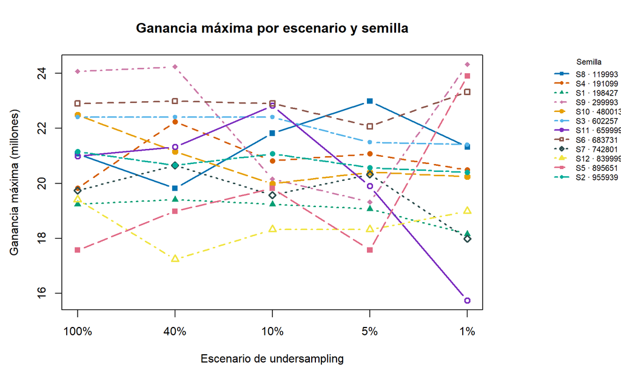

**Qué mirar:** no buscamos únicamente qué punto dio el score más alto. Nos interesa observar si la caída o estabilidad de la ganancia se repite entre semillas a medida que aumenta el undersampling.

### 7.0.1 Interpretación del gráfico

Este gráfico muestra **cómo cambia la ganancia máxima para cada semilla cuando modificamos el nivel de undersampling**.

Cada línea representa una semilla. Lo importante no es solamente cuál punto llega más alto, sino observar:

- si las líneas siguen un patrón parecido;
- si un escenario mantiene resultados similares entre semillas;
- si aparecen saltos extremos;
- y a partir de qué nivel de reducción comienza a aumentar la dispersión.

Con las 12 semillas integradas, el **10%** mantiene ganancias competitivas y presenta una variabilidad relativa baja entre semillas.

En cambio, el **1%** muestra una conducta mucho más irregular: SEM5 alcanza una ganancia muy alta, mientras otras semillas quedan bastante más abajo.

Esto refuerza una idea importante:

> **una ganancia alta en una única semilla no equivale necesariamente a estabilidad.**

La lectura conjunta de este gráfico con SD, CV y Wilcoxon permite diferenciar **nivel de ganancia** de **estabilidad de la ganancia**.

# 8 AUC

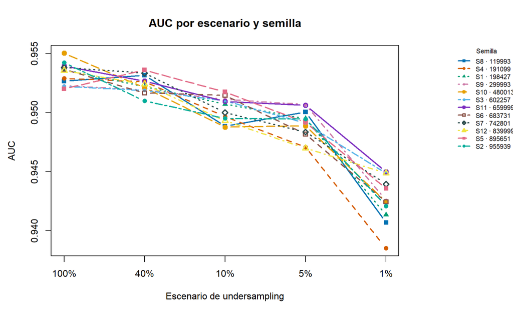

El AUC no reemplaza a la ganancia económica. Lo utilizamos como una segunda mirada para entender si la capacidad predictiva del modelo se deteriora cuando reducimos datos.

### 8.0.1 Interpretación del gráfico

Este gráfico muestra la evolución del **AUC**, es decir, la capacidad global del modelo para ordenar correctamente los casos.

A diferencia de la ganancia económica, acá se observa un patrón bastante más regular:

- `40%` permanece muy cerca del Baseline;
- `10%` presenta una caída pequeña;
- `5%` muestra un deterioro algo mayor;
- `1%` evidencia una caída más clara en prácticamente todas las semillas.

Los AUC medios actuales son:

AUC medio por escenario

| Escenario | AUC medio ↑ |
| --- | --- |
| 100% | 0.953313 |
| 40% | 0.952365 |
| 10% | 0.950247 |
| 5% | 0.948990 |
| 1% | 0.942696 |

La lectura principal es:

> **el modelo tolera bastante bien la reducción hasta 10%, pero por debajo de ese nivel empieza a perder capacidad predictiva de manera más visible.**

Este gráfico también ayuda a interpretar situaciones como SEM5 al `1%`: aunque la ganancia económica de esa corrida es muy alta, el AUC del escenario 1% sigue mostrando deterioro. Por eso no debemos elegir un escenario mirando únicamente la ganancia.

# 9 Registros utilizados

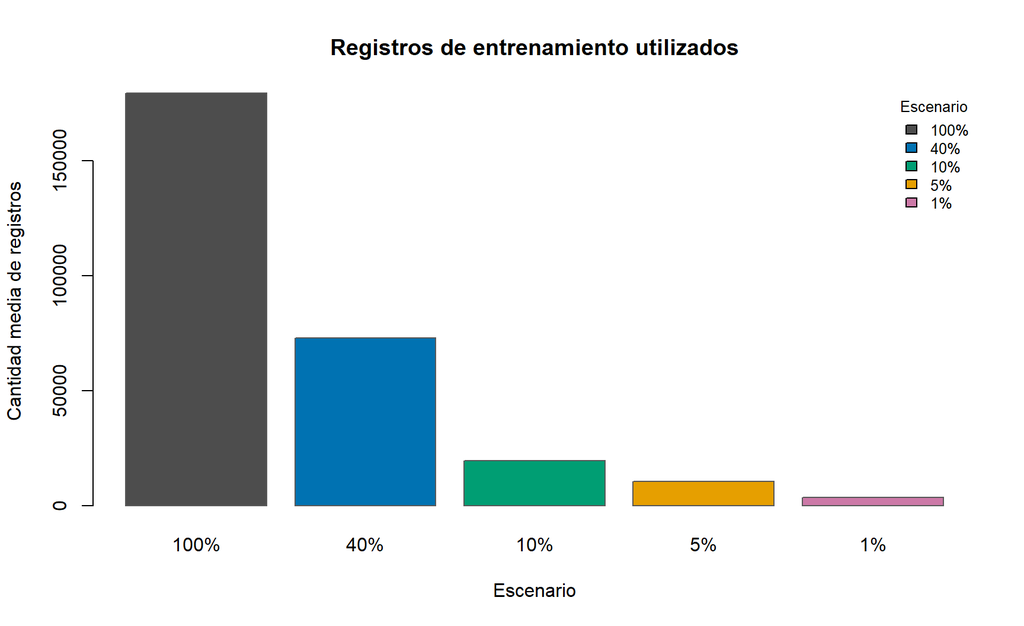

Acá visualizamos cuánto estamos reduciendo realmente el volumen de entrenamiento. Recordar: el porcentaje nominal se aplica a CONTINUA, no al total completo.

### 9.0.1 Interpretación del gráfico

Este gráfico responde directamente:

> **¿Cuánto volumen de entrenamiento estamos evitando procesar?**

Los registros medios actuales son:

Registros utilizados por escenario

| Escenario | Registros medios | % real conservado |
| --- | --- | --- |
| 100% | 179449 | 100.00 |
| 40% | 72864 | 40.60 |
| 10% | 19473 | 10.85 |
| 5% | 10601 | 5.91 |
| 1% | 3477 | 1.94 |

El salto más importante es que `10%` utiliza alrededor de una décima parte del volumen original de CONTINUA y conserva, en términos reales, aproximadamente el 11% del conjunto de entrenamiento.

Esto implica una reducción cercana al **89% de los registros respecto del Baseline**.

Por eso, si el escenario 10% mantiene una ganancia y un AUC razonablemente estables, representa una reducción muy importante del costo de entrenamiento.

# 10 Tiempo de ejecución

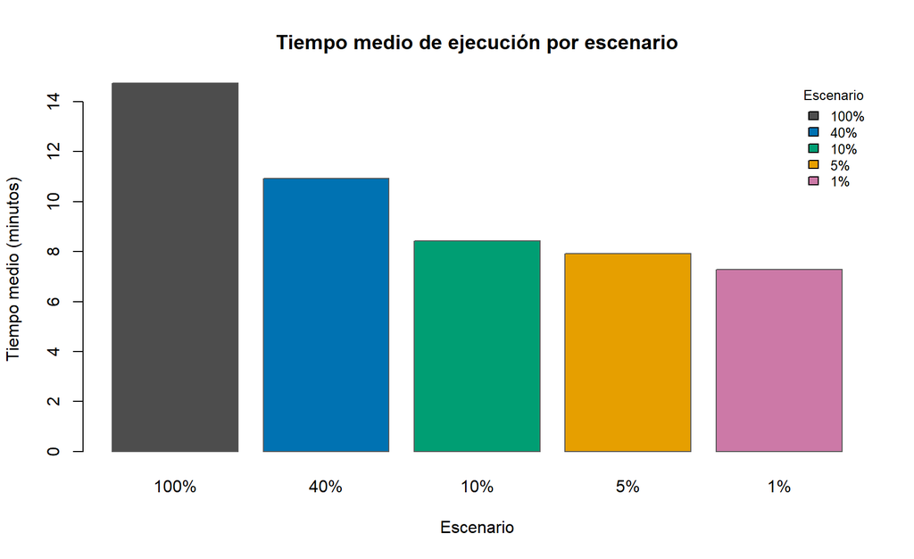

Este gráfico permite cuantificar el beneficio computacional que acompaña al undersampling.

### 10.0.1 Interpretación del gráfico

Este gráfico muestra el **tiempo medio necesario para ejecutar cada escenario**.

Los tiempos medios actuales son:

Tiempo medio de ejecución por escenario

|  | Escenario | Tiempo medio (min) ↓ |
| --- | --- | --- |
| 5 | 1% | 7.28 |
| 4 | 5% | 7.92 |
| 3 | 10% | 8.42 |
| 2 | 40% | 10.93 |
| 1 | 100% | 14.74 |

Se observa que el undersampling reduce claramente el costo computacional.

También se observa que **la reducción del tiempo no es proporcional a la reducción de registros**.

Por ejemplo, al pasar de `100%` a `10%` eliminamos aproximadamente el 89% de los registros, pero el tiempo disminuye bastante menos. Esto ocurre porque existen costos de entrenamiento, preparación y búsqueda de hiperparámetros que no desaparecen aunque el dataset sea muy pequeño.

La lectura práctica es:

> **10% logra una reducción fuerte del volumen y un ahorro importante de tiempo; bajar todavía más a 5% o 1% aporta un ahorro adicional de tiempo relativamente menor.**

# 11 Relación tiempo - ganancia

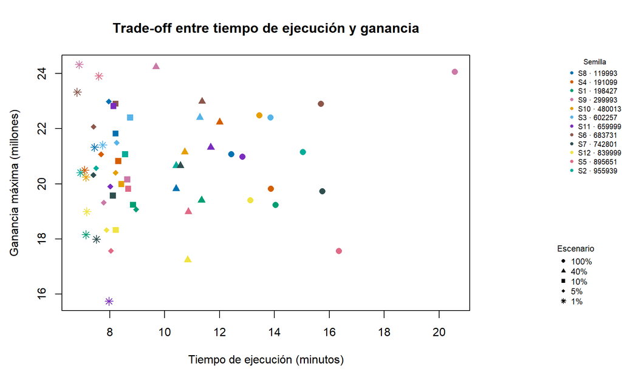

Este gráfico **no implica que la ganancia sea una función del tiempo**. Simplemente coloca juntas dos métricas reales de cada corrida para observar el compromiso entre costo computacional y resultado económico. Para evitar superposiciones, los puntos no llevan texto encima: **color = semilla** y **símbolo = escenario**, con las referencias ubicadas fuera del área del gráfico.

### 11.0.1 Interpretación del gráfico

Este gráfico combina dos objetivos:

```
eje X -> tiempo de ejecución
eje Y -> ganancia máxima
```

Conceptualmente, los puntos más atractivos son los que se ubican:

```
más arriba     -> mayor ganancia
más a la izquierda -> menor tiempo
```

No significa que el tiempo cause la ganancia. Es simplemente una forma de visualizar el **trade-off entre costo computacional y resultado económico**.

Los escenarios `40%` y `10%` tienden a desplazarse hacia tiempos menores sin mostrar una pérdida sistemática clara de ganancia.

El escenario `1%` consigue tiempos bajos, pero presenta mucha más dispersión económica entre semillas.

Esto vuelve a colocar al `10%` como un candidato interesante a **punto de equilibrio**: gran reducción de recursos con comportamiento todavía relativamente estable.

# 12 Hiperparámetros ganadores y `niter`

Configuración ganadora del Grid Search por semilla y escenario

| SEM | Semilla | Escenario | num_leaves | min_data_in_leaf | niter |
| --- | --- | --- | --- | --- | --- |
| 1 | 198427 | 100% | 256 | 64 | 546 |
| 1 | 198427 | 40% | 256 | 64 | 423 |
| 1 | 198427 | 10% | 128 | 64 | 549 |
| 1 | 198427 | 5% | 64 | 256 | 1815 |
| 1 | 198427 | 1% | 64 | 64 | 449 |
| 2 | 955939 | 100% | 256 | 64 | 420 |
| 2 | 955939 | 40% | 256 | 64 | 269 |
| 2 | 955939 | 10% | 256 | 64 | 451 |
| 2 | 955939 | 5% | 256 | 64 | 289 |
| 2 | 955939 | 1% | 64 | 64 | 368 |
| 3 | 602257 | 100% | 256 | 256 | 456 |
| 3 | 602257 | 40% | 256 | 64 | 595 |
| 3 | 602257 | 10% | 128 | 64 | 572 |
| 3 | 602257 | 5% | 64 | 64 | 778 |
| 3 | 602257 | 1% | 64 | 64 | 1146 |
| 4 | 191099 | 100% | 128 | 512 | 611 |
| 4 | 191099 | 40% | 128 | 64 | 1124 |
| 4 | 191099 | 10% | 128 | 64 | 671 |
| 4 | 191099 | 5% | 64 | 64 | 558 |
| 4 | 191099 | 1% | 64 | 64 | 834 |
| 5 | 895651 | 100% | 256 | 64 | 223 |
| 5 | 895651 | 40% | 256 | 64 | 557 |
| 5 | 895651 | 10% | 64 | 64 | 701 |
| 5 | 895651 | 5% | 128 | 64 | 386 |
| 5 | 895651 | 1% | 64 | 64 | 1128 |
| 6 | 683731 | 100% | 256 | 256 | 674 |
| 6 | 683731 | 40% | 128 | 256 | 585 |
| 6 | 683731 | 10% | 128 | 64 | 419 |
| 6 | 683731 | 5% | 256 | 64 | 366 |
| 6 | 683731 | 1% | 64 | 64 | 348 |
| 7 | 742801 | 100% | 256 | 256 | 470 |
| 7 | 742801 | 40% | 256 | 64 | 290 |
| 7 | 742801 | 10% | 256 | 64 | 313 |
| 7 | 742801 | 5% | 128 | 64 | 320 |
| 7 | 742801 | 1% | 64 | 64 | 1166 |
| 8 | 119993 | 100% | 256 | 256 | 369 |
| 8 | 119993 | 40% | 256 | 64 | 421 |
| 8 | 119993 | 10% | 128 | 64 | 223 |
| 8 | 119993 | 5% | 64 | 64 | 745 |
| 8 | 119993 | 1% | 64 | 64 | 385 |
| 9 | 299993 | 100% | 256 | 64 | 226 |
| 9 | 299993 | 40% | 128 | 64 | 233 |
| 9 | 299993 | 10% | 128 | 64 | 431 |
| 9 | 299993 | 5% | 128 | 64 | 509 |
| 9 | 299993 | 1% | 64 | 64 | 237 |
| 10 | 480013 | 100% | 256 | 256 | 421 |
| 10 | 480013 | 40% | 256 | 64 | 301 |
| 10 | 480013 | 10% | 128 | 64 | 271 |
| 10 | 480013 | 5% | 256 | 64 | 629 |
| 10 | 480013 | 1% | 64 | 64 | 655 |
| 11 | 659999 | 100% | 256 | 256 | 471 |
| 11 | 659999 | 40% | 512 | 64 | 766 |
| 11 | 659999 | 10% | 128 | 64 | 301 |
| 11 | 659999 | 5% | 128 | 64 | 463 |
| 11 | 659999 | 1% | 64 | 64 | 1591 |
| 12 | 839999 | 100% | 512 | 64 | 444 |
| 12 | 839999 | 40% | 512 | 64 | 742 |
| 12 | 839999 | 10% | 128 | 64 | 224 |
| 12 | 839999 | 5% | 256 | 64 | 215 |
| 12 | 839999 | 1% | 64 | 64 | 560 |

Estos valores son útiles para comprender el comportamiento del entrenamiento. **No significa que nosotros hayamos cambiado manualmente los hiperparámetros entre escenarios**: el mismo procedimiento de búsqueda se vuelve a ejecutar y puede seleccionar un ganador diferente.

`niter` es la mejor iteración de boosting determinada durante el entrenamiento; **no es el corte de Kaggle**.

# 13 Cortes de Kaggle

Los cortes evaluados son `800, 850, ..., 1300`. Para el análisis principal conservamos la **ganancia máxima obtenida dentro de esos 11 cortes**, pero mantenemos todo el detalle para poder revisar la curva cuando sea necesario.

Corte ganador por escenario y semilla, ordenado por ganancia (mayor a menor)

|  | Ranking | SEM | Semilla | Escenario | Ganancia máxima ↑ | Corte(s) máximo(s) | Cantidad de empates |
| --- | --- | --- | --- | --- | --- | --- | --- |
| 45 | 1 | 9 | 299993 | 1% | 24.318 | 800 | 1 |
| 42 | 2 | 9 | 299993 | 40% | 24.235 | 800 | 1 |
| 41 | 3 | 9 | 299993 | 100% | 24.068 | 800 | 1 |
| 25 | 4 | 5 | 895651 | 1% | 23.902 | 1200 | 1 |
| 30 | 5 | 6 | 683731 | 1% | 23.319 | 1100 | 1 |
| 27 | 6 | 6 | 683731 | 40% | 22.986 | 850 | 1 |
| 39 | 7 | 8 | 119993 | 5% | 22.986 | 850 | 1 |
| 26 | 8 | 6 | 683731 | 100% | 22.902 | 850 | 1 |
| 28 | 9 | 6 | 683731 | 10% | 22.902 | 850 | 1 |
| 53 | 10 | 11 | 659999 | 10% | 22.819 | 1100 | 1 |
| 46 | 11 | 10 | 480013 | 100% | 22.486 | 850 | 1 |
| 11 | 12 | 3 | 602257 | 100% | 22.403 | 850 | 1 |
| 12 | 13 | 3 | 602257 | 40% | 22.403 | 850 | 1 |
| 13 | 14 | 3 | 602257 | 10% | 22.403 | 850 | 1 |
| 17 | 15 | 4 | 191099 | 40% | 22.236 | 1250 | 1 |
| 29 | 16 | 6 | 683731 | 5% | 22.069 | 1150 | 1 |
| 38 | 17 | 8 | 119993 | 10% | 21.820 | 1150 | 1 |
| 14 | 18 | 3 | 602257 | 5% | 21.487 | 900 | 1 |
| 15 | 19 | 3 | 602257 | 1% | 21.403 | 1300 | 1 |
| 40 | 20 | 8 | 119993 | 1% | 21.320 | 950 | 1 |
| 52 | 21 | 11 | 659999 | 40% | 21.320 | 1300 | 1 |
| 6 | 22 | 2 | 955939 | 100% | 21.153 | 800 | 1 |
| 47 | 23 | 10 | 480013 | 40% | 21.153 | 800 | 1 |
| 8 | 24 | 2 | 955939 | 10% | 21.070 | 800 | 1 |
| 19 | 25 | 4 | 191099 | 5% | 21.070 | 800 | 1 |
| 36 | 26 | 8 | 119993 | 100% | 21.070 | 950 | 1 |
| 51 | 27 | 11 | 659999 | 100% | 20.987 | 1050 | 1 |
| 18 | 28 | 4 | 191099 | 10% | 20.820 | 1050 | 1 |
| 7 | 29 | 2 | 955939 | 40% | 20.654 | 950 | 1 |
| 32 | 30 | 7 | 742801 | 40% | 20.654 | 950\|1050 | 2 |
| 9 | 31 | 2 | 955939 | 5% | 20.570 | 950 | 1 |
| 20 | 32 | 4 | 191099 | 1% | 20.487 | 1050 | 1 |
| 10 | 33 | 2 | 955939 | 1% | 20.404 | 950 | 1 |
| 49 | 34 | 10 | 480013 | 5% | 20.404 | 950 | 1 |
| 34 | 35 | 7 | 742801 | 5% | 20.321 | 1050 | 1 |
| 50 | 36 | 10 | 480013 | 1% | 20.237 | 1100 | 1 |
| 43 | 37 | 9 | 299993 | 10% | 20.154 | 950 | 1 |
| 48 | 38 | 10 | 480013 | 10% | 19.987 | 850 | 1 |
| 54 | 39 | 11 | 659999 | 5% | 19.904 | 1100 | 1 |
| 16 | 40 | 4 | 191099 | 100% | 19.821 | 950 | 1 |
| 23 | 41 | 5 | 895651 | 10% | 19.821 | 800\|1250 | 2 |
| 37 | 42 | 8 | 119993 | 40% | 19.821 | 1000 | 1 |
| 31 | 43 | 7 | 742801 | 100% | 19.738 | 1100 | 1 |
| 33 | 44 | 7 | 742801 | 10% | 19.571 | 1100 | 1 |
| 2 | 45 | 1 | 198427 | 40% | 19.404 | 850 | 1 |
| 56 | 46 | 12 | 839999 | 100% | 19.404 | 850 | 1 |
| 44 | 47 | 9 | 299993 | 5% | 19.321 | 1000 | 1 |
| 1 | 48 | 1 | 198427 | 100% | 19.238 | 850 | 1 |
| 3 | 49 | 1 | 198427 | 10% | 19.238 | 850 | 1 |
| 4 | 50 | 1 | 198427 | 5% | 19.071 | 1100\|1250 | 2 |
| 22 | 51 | 5 | 895651 | 40% | 18.988 | 850 | 1 |
| 60 | 52 | 12 | 839999 | 1% | 18.988 | 1000 | 1 |
| 58 | 53 | 12 | 839999 | 10% | 18.322 | 900 | 1 |
| 59 | 54 | 12 | 839999 | 5% | 18.322 | 900 | 1 |
| 5 | 55 | 1 | 198427 | 1% | 18.155 | 900 | 1 |
| 35 | 56 | 7 | 742801 | 1% | 17.989 | 1300 | 1 |
| 21 | 57 | 5 | 895651 | 100% | 17.572 | 1100 | 1 |
| 24 | 58 | 5 | 895651 | 5% | 17.572 | 800\|1100 | 2 |
| 57 | 59 | 12 | 839999 | 40% | 17.239 | 950 | 1 |
| 55 | 60 | 11 | 659999 | 1% | 15.740 | 850 | 1 |

# 14 Comparación de escenarios todos contra todos

Primero comparamos cada escenario contra su propio Baseline (`100%`).

Eso responde:

> **¿Qué cambia respecto del escenario sin undersampling?**

Pero para estudiar correctamente el Problema #12 también necesitamos comparar **todos los escenarios entre sí**, porque buscamos detectar en qué punto la reducción de datos empieza a cambiar de manera sistemática el comportamiento del modelo.

Con cinco escenarios existen exactamente diez comparaciones:

```
100% vs 40%
100% vs 10%
100% vs 5%
100% vs 1%

40% vs 10%
40% vs 5%
40% vs 1%

10% vs 5%
10% vs 1%

5% vs 1%
```

La comparación es **pareada por semilla**.

Por ejemplo:

```
40% vs 10%

SEM1:  ganancia 40% vs ganancia 10%
SEM2:  ganancia 40% vs ganancia 10%
...
SEM11: ganancia 40% vs ganancia 10%
SEM12: ganancia 40% vs ganancia 10%
```

Nunca se compara una semilla con otra.

## 14.1 Construcción automática de las diez comparaciones

## 14.2 Resumen descriptivo de las diez comparaciones

En la tabla siguiente:

- `A gana` = cuántas semillas tuvieron mayor ganancia en el escenario A;
- `Empates` = cuántas semillas dieron exactamente la misma ganancia máxima;
- `B gana` = cuántas semillas favorecieron al escenario B;
- `Delta media` = promedio de `Ganancia A - Ganancia B`;
- `Delta mediana` = mediana de `Ganancia A - Ganancia B`.

Por lo tanto:

```
Delta > 0  -> favorece A
Delta = 0  -> comportamiento equivalente en la medida observada
Delta < 0  -> favorece B
```

Comparación descriptiva de ganancias: todos los escenarios contra todos

| Escenario A | Escenario B | N pares | A gana | Empates | B gana | Delta media | Delta mediana |
| --- | --- | --- | --- | --- | --- | --- | --- |
| 100% | 40% | 12 | 4 | 1 | 7 | -0.021 | -0.125 |
| 100% | 10% | 12 | 5 | 3 | 4 | 0.160 | 0.000 |
| 100% | 5% | 12 | 8 | 1 | 3 | 0.645 | 0.708 |
| 100% | 1% | 12 | 7 | 0 | 5 | 0.382 | 0.582 |
| 40% | 10% | 12 | 6 | 1 | 5 | 0.181 | 0.042 |
| 40% | 5% | 12 | 10 | 0 | 2 | 0.666 | 0.832 |
| 40% | 1% | 12 | 7 | 0 | 5 | 0.403 | 0.583 |
| 10% | 5% | 12 | 7 | 1 | 4 | 0.486 | 0.333 |
| 10% | 1% | 12 | 7 | 0 | 5 | 0.222 | 0.417 |
| 5% | 1% | 12 | 8 | 0 | 4 | -0.264 | 0.167 |

Esta tabla todavía **no habla de significancia estadística**. Primero nos permite ver el patrón de dirección de las diferencias entre escenarios.

## 14.3 Wilcoxon pareado - todos contra todos

Como las mismas semillas se utilizan en los cinco escenarios, corresponde una comparación **pareada**.

Para cada una de las diez parejas se aplica:

```r
wilcox.test(
  ganancia_A,
  ganancia_B,
  paired = TRUE,
  exact = FALSE
)
```

Se utiliza `exact = FALSE` porque en nuestros datos pueden existir empates o diferencias iguales a cero.

> **Alcance:** este es el análisis inferencial correspondiente a las **12 semillas integradas**. Si en el futuro se agregaran nuevas semillas, el mismo bloque se recalculará automáticamente sin cambiar la metodología.

## 14.4 Tabla de Wilcoxon

Wilcoxon pareado: 10 comparaciones ordenadas por p-value (menor a mayor)

|  | Escenario A | Escenario B | N pares | N diferencias no cero | Mediana delta | W | p-value | p-value Holm | Direccion | Evidencia |
| --- | --- | --- | --- | --- | --- | --- | --- | --- | --- | --- |
| 6 | 40% | 5% | 12 | 12 | 0.832 | 60.0 | 0.0992 | 0.9922 | 40% > 5% | Sin evidencia p<0.05 |
| 8 | 10% | 5% | 12 | 11 | 0.333 | 47.0 | 0.2132 | 1.0000 | 10% > 5% | Sin evidencia p<0.05 |
| 4 | 100% | 1% | 12 | 12 | 0.582 | 54.0 | 0.2391 | 1.0000 | 100% > 1% | Sin evidencia p<0.05 |
| 3 | 100% | 5% | 12 | 11 | 0.708 | 46.0 | 0.2477 | 1.0000 | 100% > 5% | Sin evidencia p<0.05 |
| 7 | 40% | 1% | 12 | 12 | 0.583 | 48.0 | 0.4802 | 1.0000 | 40% > 1% | Sin evidencia p<0.05 |
| 9 | 10% | 1% | 12 | 12 | 0.417 | 47.5 | 0.5047 | 1.0000 | 10% > 1% | Sin evidencia p<0.05 |
| 10 | 5% | 1% | 12 | 12 | 0.167 | 43.0 | 0.7537 | 1.0000 | 5% > 1% | Sin evidencia p<0.05 |
| 2 | 100% | 10% | 12 | 9 | 0.000 | 25.0 | 0.7671 | 1.0000 | Sin dirección central | Sin evidencia p<0.05 |
| 1 | 100% | 40% | 12 | 11 | -0.125 | 30.0 | 0.7897 | 1.0000 | 40% > 100% | Sin evidencia p<0.05 |
| 5 | 40% | 10% | 12 | 11 | 0.042 | 34.5 | 0.8939 | 1.0000 | 40% > 10% | Sin evidencia p<0.05 |

### 14.4.1 Resultado global de las 10 comparaciones

Con las **12 semillas integradas**, las diez comparaciones se apoyan en **12 pares** cada una.

- Comparaciones con `p-value < 0.05`: **0 de 10**.
- Comparaciones con `p-value Holm < 0.05`: **0 de 10**.
- La comparación con menor `p-value` es **40% vs 5%**, con `p = 0.0992 y`p Holm = 0.9922.

La interpretación conjunta es importante:

> **Con estas 12 semillas no aparece evidencia estadística suficiente para afirmar que la ganancia económica difiera de manera sistemática entre alguno de los pares de escenarios al nivel 0.05.**

Esto **no demuestra que todos los escenarios sean iguales**. Significa que la decisión no debe basarse en una supuesta diferencia estadísticamente significativa de ganancia que nuestros datos no muestran. Por eso el P12 debe resolverse combinando:

1. nivel y estabilidad de la ganancia;
2. AUC;
3. reducción de registros;
4. tiempo de ejecución;
5. patrón pareado entre semillas.

### 14.4.2 Cómo leer esta tabla

El `p-value` responde:

> **¿Las diferencias pareadas de ganancia observadas entre estos dos escenarios muestran evidencia de un cambio sistemático entre semillas?**

### 14.4.3 Qué significa realmente el p-value

El p-value **no indica cuál escenario es mejor** y tampoco significa que un escenario sea “más certero”.

En nuestro Wilcoxon, la hipótesis nula puede expresarse de manera simple como:

> **Entre el escenario A y el escenario B no existe una diferencia sistemática de ganancia entre semillas.**

Entonces:

```
p-value pequeño
      |
      v
mayor evidencia contra la hipótesis nula
      |
      v
hay indicios de que A y B se comportan de manera diferente

p-value grande
      |
      v
no hay evidencia suficiente para afirmar
que A y B tengan una diferencia sistemática
```

Por lo tanto:

> **un p-value más cercano a cero NO significa que esa fila sea “la mejor”.**

Para saber hacia qué escenario apunta la diferencia hay que mirar también:

```
A gana
B gana
Empates
Mediana delta
```

La dirección se interpreta así:

```
Mediana delta > 0 -> favorece A
Mediana delta = 0 -> no aparece una dirección central clara
Mediana delta < 0 -> favorece B
```

### 14.4.4 Ejemplo real: 40% vs 5%

Con las 12 semillas integradas:

```
40% vs 5%

A gana        = 10
Empates       = 0
B gana        = 2
Mediana delta = 0.832
p-value       = 0.0992
p-value Holm  = 0.9922
```

Descriptivamente, el patrón es fuerte si todas o casi todas las semillas favorecen al mismo escenario.

El p-value original indica qué tan compatible resulta ese patrón con la hipótesis de “no diferencia sistemática”.

### 14.4.5 ¿Qué es el p-value Holm?

En este trabajo hacemos **10 comparaciones todos contra todos**.

Cuantas más pruebas realizamos, mayor es la probabilidad de obtener algún p-value pequeño simplemente por azar.

La corrección de **Holm** hace el criterio más exigente para controlar este problema de comparaciones múltiples.

Conceptualmente:

```
1 comparación
     |
     v
menor riesgo de falso positivo

10 comparaciones
     |
     v
mayor riesgo de encontrar algún p pequeño por azar

corrección Holm
     |
     v
criterio más exigente
```

Para `40% vs 5%`, el valor sin corrección es **0.0992**, mientras que el valor ajustado por Holm es **0.9922**.

Si el p-value original fuera menor a `0.05`, pero el valor Holm fuera mayor, la lectura correcta sería:

> **existe una señal descriptiva interesante, pero todavía no alcanza para declararla estadísticamente significativa después de considerar las diez comparaciones simultáneas.**

### 14.4.6 Ejemplo real: 40% vs 10%

Con las 12 semillas integradas:

```
A gana        = 6
Empates       = 1
B gana        = 5
Mediana delta = 0.042
p-value       = 0.8939
```

Si el patrón se reparte entre A y B y la mediana es cercana a cero, eso indica que **no aparece una dirección consistente de ganancia entre ambos escenarios**.

Para el P12 esto puede ser muy importante: si `40%` y `10%` producen ganancias similares, pero `10%` utiliza muchos menos registros, el escenario 10% puede resultar operacionalmente mucho más atractivo.

### 14.4.7 Ejemplo real: 100% vs 10%

Con las 12 semillas integradas:

```
A gana        = 5
Empates       = 3
B gana        = 4
Mediana delta = 0.000
p-value       = 0.7671
```

Si no encontramos evidencia de una diferencia sistemática frente al Baseline, eso **no significa que los escenarios sean matemáticamente idénticos**.

Significa que, con las semillas disponibles, no tenemos evidencia suficiente para afirmar que sus ganancias difieran de forma sistemática.

Y para nuestro experimento eso puede ser justamente una señal favorable si, al mismo tiempo, reducimos cerca del 89% de los registros.

### 14.4.8 Cuidado especial con el escenario 1%

El `1%` puede producir alguna ganancia extraordinariamente alta, pero también muestra:

- mayor dispersión de ganancia;
- mayor CV;
- peor AUC medio;
- diferencias importantes entre semillas.

Por eso su media puede verse muy influida por una corrida excepcional.

En estos casos conviene mirar especialmente:

```
mediana
SD
CV
A gana / B gana
AUC
```

y no solamente la media o el p-value.

### 14.4.9 Orden recomendado para interpretar cada comparación

Para nuestro P12 conviene mirar:

```
1. A gana / B gana / Empates
2. Mediana delta
3. SD y CV
4. Magnitud de las diferencias
5. p-value
6. p-value Holm
7. AUC
8. Registros utilizados
9. Tiempo de ejecución
```

La pregunta central no es:

> “¿Qué fila tiene el p-value más bajo?”

La pregunta es:

> **¿Hasta cuánto podemos reducir los datos sin deteriorar de manera relevante y estable el modelo?**

Con las **12 semillas integradas**, la interpretación se realiza sobre el conjunto completo actualmente disponible:

- las comparaciones son pareadas y usan 12 pares por escenario;
- pueden existir empates o diferencias iguales a cero;
- el Wilcoxon se interpreta junto con la magnitud y dirección de las diferencias;
- la conclusión no se decide únicamente por el `p-value`, sino también por dispersión, AUC y ahorro de recursos;
- si en el futuro se incorporaran nuevas semillas, el informe se recalcularía automáticamente sin cambiar la metodología.

El `p-value Holm` se conserva como información adicional porque estamos realizando diez comparaciones simultáneamente. No reemplaza el criterio que finalmente indique el profesor para el trabajo.

## 14.5 Qué archivos nuevos deja esta sección

Después de cada Knit se actualizan automáticamente:

```
91_ANALISIS/00_GLOBAL/
├── detalle_comparaciones_todos_contra_todos_P12.csv
├── comparaciones_todos_contra_todos_P12.csv
└── wilcoxon_todos_contra_todos_P12.csv
```

Por lo tanto, cuando incorporemos nuevas semillas no habrá que rehacer las comparaciones manualmente:

```
nuevos resumen_integrado
        |
        v
tabla_maestra
        |
        v
Knit
        |
        +--> comparaciones todos contra todos
        |
        +--> Wilcoxon pareado
        |
        v
tablas actualizadas automáticamente
```

# 15 Síntesis integral de resultados

Esta sección reúne las métricas principales en una sola tabla para estudiar el experimento **a golpe de vista**.

Síntesis integral SEM1–SEM12, ordenada por ganancia media

|  | Escenario | Rank ganancia | Ganancia media ↑ | Mediana ↑ | SD ↓ | CV (%) ↓ | Rank estabilidad | AUC medio ↑ | Rank AUC | % real conservado | Reducción registros (%) ↑ | Tiempo medio (min) ↓ | Ahorro tiempo (%) ↑ |
| --- | --- | --- | --- | --- | --- | --- | --- | --- | --- | --- | --- | --- | --- |
| 2 | 40% | 1 | 20.924 | 20.904 | 1.915 | 9.2 | 4 | 0.952365 | 2 | 40.60 | 59.4 | 10.93 | 25.9 |
| 1 | 100% | 2 | 20.904 | 21.029 | 1.847 | 8.8 | 3 | 0.953313 | 1 | 100.00 | 0.0 | 14.74 | 0.0 |
| 3 | 10% | 3 | 20.744 | 20.487 | 1.485 | 7.2 | 1 | 0.950247 | 3 | 10.85 | 89.1 | 8.42 | 42.9 |
| 5 | 1% | 4 | 20.522 | 20.445 | 2.566 | 12.5 | 5 | 0.942696 | 5 | 1.94 | 98.1 | 7.28 | 50.6 |
| 4 | 5% | 5 | 20.258 | 20.363 | 1.549 | 7.6 | 2 | 0.948990 | 4 | 5.91 | 94.1 | 7.92 | 46.3 |

### 15.0.1 Lectura rápida de la síntesis

- **Mayor ganancia media:** 40%.
- **Mayor estabilidad relativa de ganancia (menor CV):** 10%.
- **Mayor AUC medio:** 100%.
- En `10%`, la reducción media de registros respecto del Baseline es de aproximadamente **89.1%**.
- En `10%`, el ahorro medio de tiempo es de aproximadamente **42.9%**.
- La diferencia de ganancia media `10% - 100%` es **-0.160 millones**.
- La diferencia de AUC medio `10% - 100%` es **-0.003066**.

La lectura conjunta de estos indicadores permite separar tres ideas que no deben confundirse:

```
GANANCIA     -> resultado económico
ESTABILIDAD  -> cuánto cambia ese resultado entre semillas
AUC          -> capacidad predictiva global
RECURSOS     -> registros y tiempo requeridos
```

Por eso un escenario no se considera atractivo solamente por ocupar el primer lugar en una métrica aislada.

# 16 Control de consistencia para la comparación estadística

Control previo a la inferencia estadística

| control | resultado |
| --- | --- |
| Semillas completas disponibles | 12 |
| Los 5 escenarios están presentes | SI |
| Cada semilla aporta los mismos 5 escenarios | SI |
| Wilcoxon pareado ejecutado | SI |

Este informe ejecuta automáticamente el **Wilcoxon pareado con las 12 semillas completas disponibles**.

La comparación es **pareada por semilla**, porque los cinco escenarios fueron ejecutados sobre las mismas semillas. Si luego se incorporan nuevas semillas, el análisis se recalcula automáticamente al volver a hacer Knit.

# 17 Estado del conjunto analizado

```
## SEMILLAS COMPLETAS:
```

```
## SEM1, SEM2, SEM3, SEM4, SEM5, SEM6, SEM7, SEM8, SEM9, SEM10, SEM11, SEM12
```

```
## SEMILLAS TODAVÍA NO COMPLETAS:
```

```
## Ninguna
```

Con cada actualización de `90_RESULTADOS` basta con volver a hacer **Knit**. No hay que reconstruir tablas a mano.

# 18 Archivos automáticos que deja este informe

Cada ejecución actualiza:

```
91_ANALISIS/
└── 00_GLOBAL/
    ├── estado_semillas_P12.csv
    ├── tabla_maestra_P12.csv
    ├── resumen_por_escenario_P12.csv
    ├── comparacion_vs_baseline_P12.csv
    ├── detalle_cortes_todas_semillas.csv
    ├── detalle_comparaciones_todos_contra_todos_P12.csv
    ├── comparaciones_todos_contra_todos_P12.csv
    ├── wilcoxon_todos_contra_todos_P12.csv
    └── GRAFICOS/
        ├── 01_ganancia_por_semilla.png
        ├── 02_auc_por_semilla.png
        ├── 03_registros_promedio.png
        ├── 04_tiempo_promedio.png
        └── 05_tiempo_vs_ganancia.png
```

# 19 Mapa mental del P12

```
             MISMO EXPERIMENTO P12
          +-----------+-----------+
          |                       |
    semillas Victor          semillas David
          |                       |
          +-----------+-----------+
                      v
               5 ESCENARIOS
          100 - 40 - 10 - 5 - 1
                      v
          resultado por semilla
       +--------------+--------------+
       |              |              |
    ganancia         AUC        recursos/tiempo
       |              |              |
       +--------------+--------------+
                      v
            ESTABILIDAD DEL MODELO
                      v
          COMPARACIÓN ESTADÍSTICA
                      v
              CONCLUSIÓN P12
```

## 19.1 Idea fundamental

No buscamos elegir el escenario con el número más alto de una corrida aislada.

Buscamos determinar, mediante **varias semillas del mismo experimento**, hasta qué nivel puede reducirse la información de entrenamiento manteniendo un comportamiento suficientemente estable, y cuánto recurso computacional se ahorra a cambio.

Este R Markdown funciona como **documento de análisis y control reproducible**: los scripts producen los datos; el informe los ordena, los grafica, ejecuta las comparaciones estadísticas y conserva la trazabilidad de cómo llegamos a cada conclusión.

## 19.2 Lectura con las 12 semillas integradas

La evidencia conjunta de las 12 semillas muestra el siguiente patrón de trabajo:

```
100%
  |
  v
40%  -> comportamiento estable
  |
  v
10%  -> todavía estable + fuerte reducción de recursos
  |
  v
-----------------------------
posible zona de quiebre
-----------------------------
  |
  v
5%   -> comienzan señales más claras de deterioro
  |
  v
1%   -> mayor inestabilidad
```

La conclusión integrada del análisis actual es:

> **Con las 12 semillas analizadas, el escenario 10% aparece como el compromiso más equilibrado entre ganancia, estabilidad, AUC y costo computacional. La ganancia económica no muestra diferencias estadísticamente significativas entre los escenarios en las diez comparaciones de Wilcoxon, pero el AUC se deteriora progresivamente al aumentar el undersampling y el escenario 1% presenta la mayor variabilidad relativa. Bajar de 10% a 5% o 1% reduce algo más los recursos, pero ese ahorro adicional debe evaluarse frente a la pérdida de AUC, la menor ganancia media observada en 5% y la mayor inestabilidad observada en 1%.**

Esta conclusión resume el **análisis completo del conjunto SEM1..SEM12 actualmente disponible**. Si en el futuro se incorporaran nuevas semillas, el informe se recalcularía automáticamente y la conclusión debería actualizarse con esa nueva evidencia.